# The Full House Model for cross-era comparisons of baseball players (part I: results and the model)

Daniel J. Eck and Shen Yan and Adrian Burgos Jr. and Christopher Kinson and Brandon Niedert

Comparing baseball players across eras remains one of the most elusive challenges for Statistical methodologies, especially when examining the game’s statistical history across the color line and the professional game’s segregated and integrated eras. The exercise produces fun and at time poignant debates about the greatness of players who did not necessarily face each other on the baseball diamonds. The challenge of assessing performance and the statistical record has broader social impacts for a sport with a history of racial segregation and exclusion. Baseball fans, journalists, and historians have continued to debate just how good were those major leaguers like Babe Ruth, Ty Cobb, or even Ted Williams who did not have to face off against Satchel Paige, “Smokey” Joe Williams, or José Méndez during the prime of the professional careers. Conversely, there has also lingered a debate about how Negro League greats Oscar Charleston, Josh Gibson, or Martin Dihigo would have performed in Major League Baseball (MLB) without the barriers created by MLB’s color line and the segregationist practices that predominated in U.S. society.

Revisiting these debates has its merits for several reasons. Baseball historians and scholars have continued to refine their statistical approaches and tools to examine baseball’s past and statistical record. As discussed below, complex formulas have sought to account for ballpark factors, the shifting size of the talent pools, and myriad ways the game play and managing has evolved, among other factors. The effort here has been inspired by the goal of not privileging the racially exclusionary era of Major League Baseball when competition was artificially restricted by its color line, meaning that those who performed during that era did not compete against the very best players in the game. Part of the challenge we faced in thinking through how to account for these changes in a manner that levels the playing field when it comes to the statistical record and the racial realities of the past and present.

Recently it was shown that previous era-adjustment approaches [struggle](https://community.fangraphs.com/challenging-war-and-other-statistics-as-era-adjustment-tools/) in their aim to properly compare players across eras (peer-reviewed version [here](https://www.tandfonline.com/doi/full/10.1080/09332480.2020.1726114)). A main reason for these struggles is that it is difficult to account for the evolution of baseball and the evolution of talent pool of players that feeds into the NL/AL*. In this article we motivate novel methodology that more properly compares players across eras through a principled balancing of how well one performs “vs their peers” and the size of the talent pool. This methodology is a crystallization of the conceptual ideas put forth by Stephen Jay Gould. We name this method the [Full House Model](https://arxiv.org/abs/2207.11332) in [his honor](https://en.wikipedia.org/wiki/Full_House:_The_Spread_of_Excellence_from_Plato_to_Darwin). Previous era-adjustment approaches engage with Gould’s ideas, but they, and Gould, do not go far enough. In one way or another, previous era-adjustment approaches implicitly (or explicitly) suppose that the composition of NL/AL players have remained relatively stable throughout baseball history. The Full House Model goes a step further to connect those that reached the NL/AL to the talent pool of players’ contemporaries. Additionally, the Full House Model requires no knowledge of the distribution of any baseball metric and can thus be used in settings that are difficult for existing modeling techniques, including Bayesian hierarchical models. Wins above replacement (WAR) fall into such a setting. Our approach reveals a radical reranking of the greatest players when players’ metrics are placed within the same context. Notably, we observe that African and Latin American players sit atop the rankings lists of several important metrics including WAR.

This article is part 1 of a 3 part series. In this part we discuss new rankings, the origins, mechanics, and justification of the Full House Model, and other era-adjustment approaches which have fallen short in their aim to make sensible cross-era comparisons. Part 2 of this series will provide a mostly whimsical discussion of interesting careers, HOF cases, and cross-era debates. Part 3 of this series will provide serious social commentary. In all parts of the series, the primary focus is that nostalgia and currently existing statistics ranging from batting average to WAR to peer-reviewed methodological techniques which appear in top academic journals have failed in their ability to compare players across eras, and that our Full House Model is a giant first step in reconciling this consensus failure.

* Note that we say NL/AL to distinguish from the recent addition of the Negro Leagues to the MLB. Era-adjustments for Negro Leagues are still under development.

## Results: the new greatest players of all-time

We present some of the many results of our era-adjustment technique before we dive into the nuts and bolts of its derivations. At the time that this was written we apply our era-adjustment technique to FanGraphs wins above replacement (fWAR), Baseball Reference wins above replacement (bWAR), home runs, batting averages, on base percentage, earned run average, and strikeouts. We show a revised era-adjusted ranking for each of these career statistics. These results are depicted in the next few tables. What we see is an eye-opening discrepancy between the era-adjusted rankings and the raw rankings which exhibit era biases. Note that the statistics that we obtain are computed as if every career started in 1977. This starting point is chosen for stability between hitters and pitching and stability in the overall rankings (we will expand on this point below). We apply handedness specific park factors for batting average and home runs and park factors for ERA. Also note that we project plate appearances, at bats, and innings to the context of the projected season.

### Top 10 batting careers by era-adjusted bWAR (ebWAR)

| name | PA | AB | H | HR | BB | BA | OBP | ebWAR | efWAR |
| --- | --- | --- | --- | --- | --- | --- | --- | --- | --- |
| Barry Bonds | 11908 | 9484 | 2869 | 714 | 2223 | 0.303 | 0.437 | 154.80 | 152.69 |
| Willie Mays | 11960 | 10335 | 3216 | 607 | 1477 | 0.311 | 0.397 | 145.47 | 138.04 |
| Henry Aaron | 12975 | 11448 | 3587 | 714 | 1355 | 0.313 | 0.384 | 129.65 | 125.00 |
| Alex Rodriguez | 11479 | 9749 | 2914 | 597 | 1427 | 0.299 | 0.394 | 121.01 | 116.66 |
| Babe Ruth | 9665 | 7842 | 2293 | 706 | 1667 | 0.292 | 0.419 | 111.25 | 109.95 |
| Albert Pujols | 12333 | 10628 | 3315 | 660 | 1474 | 0.312 | 0.398 | 111.03 | 97.29 |
| Mike Schmidt | 9716 | 7992 | 2164 | 561 | 1521 | 0.271 | 0.388 | 110.43 | 107.80 |
| Rickey Henderson | 12978 | 10540 | 3037 | 312 | 2243 | 0.288 | 0.415 | 107.79 | 106.86 |
| Stan Musial | 12015 | 10681 | 3268 | 434 | 1193 | 0.306 | 0.377 | 103.06 | 98.33 |
| Adrian Beltre | 11302 | 10052 | 2971 | 442 | 1036 | 0.296 | 0.364 | 98.70 | 88.84 |

### Top 10 batting careers by era-adjusted fWAR (efWAR)

| name | PA | AB | H | HR | BB | BA | OBP | ebWAR | efWAR |
| --- | --- | --- | --- | --- | --- | --- | --- | --- | --- |
| Barry Bonds | 11908 | 9484 | 2869 | 714 | 2223 | 0.303 | 0.437 | 154.80 | 152.69 |
| Willie Mays | 11960 | 10335 | 3216 | 607 | 1477 | 0.311 | 0.397 | 145.47 | 138.04 |
| Henry Aaron | 12975 | 11448 | 3587 | 714 | 1355 | 0.313 | 0.384 | 129.65 | 125.00 |
| Alex Rodriguez | 11479 | 9749 | 2914 | 597 | 1427 | 0.299 | 0.394 | 121.01 | 116.66 |
| Babe Ruth | 9665 | 7842 | 2293 | 706 | 1667 | 0.292 | 0.419 | 111.25 | 109.95 |
| Mike Schmidt | 9716 | 7992 | 2164 | 561 | 1521 | 0.271 | 0.388 | 110.43 | 107.80 |
| Rickey Henderson | 12978 | 10540 | 3037 | 312 | 2243 | 0.288 | 0.415 | 107.79 | 106.86 |
| Ted Williams | 9254 | 7528 | 2333 | 506 | 1662 | 0.310 | 0.436 | 96.09 | 100.23 |
| Stan Musial | 12015 | 10681 | 3268 | 434 | 1193 | 0.306 | 0.377 | 103.06 | 98.33 |
| Albert Pujols | 12333 | 10628 | 3315 | 660 | 1474 | 0.312 | 0.398 | 111.03 | 97.29 |

### Top 10 era-adjusted home runs

| name | PA | AB | H | HR | BB | BA | OBP | ebWAR | efWAR |
| --- | --- | --- | --- | --- | --- | --- | --- | --- | --- |
| Barry Bonds | 11908 | 9484 | 2869 | 714 | 2223 | 0.303 | 0.437 | 154.80 | 152.69 |
| Henry Aaron | 12975 | 11448 | 3587 | 714 | 1355 | 0.313 | 0.384 | 129.65 | 125.00 |
| Babe Ruth | 9665 | 7842 | 2293 | 706 | 1667 | 0.292 | 0.419 | 111.25 | 109.95 |
| Albert Pujols | 12333 | 10628 | 3315 | 660 | 1474 | 0.312 | 0.398 | 111.03 | 97.29 |
| Willie Mays | 11960 | 10335 | 3216 | 607 | 1477 | 0.311 | 0.397 | 145.47 | 138.04 |
| Alex Rodriguez | 11479 | 9749 | 2914 | 597 | 1427 | 0.299 | 0.394 | 121.01 | 116.66 |
| Mike Schmidt | 9716 | 7992 | 2164 | 561 | 1521 | 0.271 | 0.388 | 110.43 | 107.80 |
| Frank Robinson | 11161 | 9464 | 2795 | 547 | 1381 | 0.295 | 0.392 | 98.06 | 94.60 |
| Ken Griffey Jr. | 10662 | 9180 | 2624 | 541 | 1292 | 0.286 | 0.375 | 91.49 | 82.10 |
| David Ortiz | 9536 | 8015 | 2306 | 538 | 1389 | 0.288 | 0.392 | 67.77 | 62.61 |

### Top 10 era-adjusted batting averages (minimum 4000 AB)

| name | PA | AB | H | HR | BB | BA | OBP | ebWAR | efWAR |
| --- | --- | --- | --- | --- | --- | --- | --- | --- | --- |
| Tony Gwynn | 9604 | 8627 | 2959 | 120 | 823 | 0.343 | 0.398 | 72.37 | 65.97 |
| Rod Carew | 10217 | 8979 | 2938 | 133 | 1021 | 0.327 | 0.395 | 79.36 | 70.92 |
| Ichiro Suzuki | 10274 | 9237 | 3020 | 194 | 884 | 0.327 | 0.387 | 75.87 | 71.89 |
| Ty Cobb | 11720 | 10693 | 3477 | 186 | 642 | 0.325 | 0.369 | 91.72 | 87.21 |
| Jose Altuve | 6422 | 5699 | 1836 | 173 | 598 | 0.322 | 0.389 | 48.93 | 48.33 |
| Miguel Cabrera | 10912 | 9375 | 2991 | 500 | 1368 | 0.319 | 0.406 | 83.16 | 80.77 |
| Mike Trout | 5739 | 4628 | 1477 | 316 | 973 | 0.319 | 0.442 | 78.94 | 79.46 |
| Buster Posey | 5286 | 4550 | 1445 | 182 | 639 | 0.318 | 0.402 | 50.11 | 60.83 |
| Wade Boggs | 10395 | 8853 | 2810 | 133 | 1394 | 0.317 | 0.408 | 93.23 | 90.45 |
| Roberto Clemente | 9728 | 8934 | 2834 | 288 | 657 | 0.317 | 0.364 | 92.00 | 79.37 |

### Top 10 era-adjusted on base percentage (minimum 4000 PA)

| name | PA | AB | H | HR | BB | BA | OBP | ebWAR | efWAR |
| --- | --- | --- | --- | --- | --- | --- | --- | --- | --- |
| Mike Trout | 5739 | 4628 | 1477 | 316 | 973 | 0.319 | 0.442 | 78.94 | 79.46 |
| Barry Bonds | 11908 | 9484 | 2869 | 714 | 2223 | 0.303 | 0.437 | 154.80 | 152.69 |
| Joey Votto | 8128 | 6575 | 2047 | 306 | 1441 | 0.311 | 0.437 | 75.47 | 70.43 |
| Ted Williams | 9254 | 7528 | 2333 | 506 | 1662 | 0.310 | 0.436 | 96.09 | 100.23 |
| Frank Thomas | 9666 | 7869 | 2409 | 474 | 1589 | 0.306 | 0.423 | 79.53 | 76.38 |
| Mickey Mantle | 9335 | 7651 | 2307 | 518 | 1610 | 0.302 | 0.422 | 94.90 | 95.37 |
| Jason Giambi | 7933 | 6354 | 1860 | 374 | 1312 | 0.293 | 0.422 | 59.80 | 57.45 |
| Edgar Martinez | 8164 | 6754 | 2100 | 283 | 1234 | 0.311 | 0.420 | 72.92 | 68.38 |
| Babe Ruth | 9665 | 7842 | 2293 | 706 | 1667 | 0.292 | 0.419 | 111.25 | 109.95 |
| Lance Berkman | 7367 | 6033 | 1801 | 331 | 1213 | 0.299 | 0.418 | 58.75 | 59.96 |
| Bryce Harper | 5652 | 4589 | 1348 | 267 | 971 | 0.294 | 0.418 | 49.81 | 52.11 |

### Top 10 era-adjusted hits

| name | PA | AB | H | HR | BB | BA | OBP | ebWAR | efWAR |
| --- | --- | --- | --- | --- | --- | --- | --- | --- | --- |
| Pete Rose | 13542 | 11996 | 3735 | 191 | 1335 | 0.311 | 0.383 | 78.41 | 77.12 |
| Henry Aaron | 12975 | 11448 | 3587 | 714 | 1355 | 0.313 | 0.384 | 129.65 | 125.00 |
| Ty Cobb | 11720 | 10693 | 3477 | 186 | 642 | 0.325 | 0.369 | 91.72 | 87.21 |
| Albert Pujols | 12333 | 10628 | 3315 | 660 | 1474 | 0.312 | 0.398 | 111.03 | 97.29 |
| Stan Musial | 12015 | 10681 | 3268 | 434 | 1193 | 0.306 | 0.377 | 103.06 | 98.33 |
| Willie Mays | 11960 | 10335 | 3216 | 607 | 1477 | 0.311 | 0.397 | 145.47 | 138.04 |
| Eddie Murray | 12365 | 10892 | 3198 | 510 | 1328 | 0.294 | 0.368 | 69.48 | 72.98 |
| Paul Molitor | 11652 | 10318 | 3172 | 239 | 1103 | 0.307 | 0.373 | 74.48 | 65.40 |
| Derek Jeter | 11341 | 9854 | 3111 | 272 | 1180 | 0.316 | 0.396 | 83.46 | 80.49 |
| Cal Ripken Jr. | 12351 | 11017 | 3073 | 411 | 1131 | 0.279 | 0.346 | 98.55 | 96.37 |

There are many important changes to note. First and foremost we see that great African American and Latin American players sit atop the era-adjusted WAR rankings. Moreover, it is not just one guy up top, it is four! Barry Bonds, Willie Mays, Hank Aaron, and Alex Rodriguez. This constitutes an important reversal in who we idolize as the pinnacle of achievement. The greatest athletic prowess that should be emulated is that of the best African American and Latin American ball players. Even if one “accounts for steroids” and removes Bonds and Rodriguez from consideration, then it’s still Mays and Aaron. Willie Mays and Hank Aaron are the players who, in fact, [played the game the right way](https://andscape.com/features/cc-sabathia-on-the-pressure-black-athletes-face-to-play-baseball-the-white-way/) and were also part of the pioneering generation that racially integrated the NL/AL.

As mentioned above, Babe Ruth is not considered the best batter by our versions of era-adjusted WAR, he falls to 5th best. So how is this the case? The method balances Ruth’s superior achievements against his inferior peers. That balance still comes out in Ruth’s favor, his unprecedented and unreplicated dominance against his peers is enough to offset the harsh penalties that our method imposes upon a career that began before baseball games were broadcasted on the radio.

From the homerun rankings we see that Hank Aaron and Barry Bonds are tied, each with 714 era-adjusted home runs which is of course itself [a famous number](https://www.history.com/this-day-in-history/babe-ruth-hits-last-home-run)! The homerun rankings well demonstrate the mechanics of the Full House Model. Relative to more modern players, Hank Aaron’s homerun ability is penalized. Yet his home run hitting ability was above his peers so that when we era-adjust his career with a 1977 starting point, he is on top of the career rankings with a slightly lower career total than what was observed. On the other hand, Barry Bond’s most prolific home run hitting seasons occurred during a league-wide boon for home run hitting. Although Bonds stood above his peers, his dominance over his peers is much less pronounced than what it would first appear. Thus the balance of a player’s standing relative to their peers within a specific context and the competitive of the NL/AL tips in the favor of Hank Aaron.

The batting average and on-base percentage rankings are nearly a complete departure from the raw rankings. There are several interesting points to note. First of all, modern players Tony Gwynn and Mike Trout, respectively, sit atop the era-adjusted rankings of batting average and on-base percentage. Joey Votto closely trails Trout in the era-adjusted on-base percentage rankings. Legendary older players Ty Cobb and Ted Williams both fall from first in the raw rankings to fourth in the era-adjusted rankings for, respectively, batting average and on-base percentage. Interestingly, [Bryce Harper](https://www.youtube.com/watch?v=Cfr2G2pMtnY&ab_channel=ForzanoProductions) currently sits at tied for 10th in career era-adjusted on-base percentage.

We now move to pitching.

## Top 10 pitching careers by ebWAR

| name | IP | ER | ERA | K | K9 | ebWAR | efWAR |
| --- | --- | --- | --- | --- | --- | --- | --- |
| Roger Clemens | 5062 | 1666 | 2.96 | 4453 | 7.9 | 141.78 | 131.18 |
| Greg Maddux | 5250 | 1753 | 3.01 | 3439 | 5.9 | 111.58 | 115.29 |
| Randy Johnson | 4326 | 1468 | 3.05 | 4465 | 9.3 | 105.31 | 100.63 |
| Tom Seaver | 4324 | 1497 | 3.12 | 3329 | 6.9 | 98.16 | 83.41 |
| Mike Mussina | 3861 | 1337 | 3.12 | 2746 | 6.4 | 91.07 | 84.30 |
| Pedro Martinez | 3100 | 843 | 2.45 | 2981 | 8.7 | 89.13 | 78.02 |
| Walter Johnson | 4543 | 1762 | 3.49 | 3537 | 7.0 | 88.90 | 86.30 |
| Lefty Grove | 3533 | 1326 | 3.38 | 2432 | 6.2 | 87.67 | 83.52 |
| Cy Young | 4794 | 1843 | 3.46 | 2959 | 5.6 | 87.09 | 91.41 |
| Curt Schilling | 3437 | 1136 | 2.97 | 3032 | 7.9 | 86.64 | 77.36 |

## Top 10 pitching careers by efWAR

| name | IP | ER | ERA | K | K9 | ebWAR | efWAR |
| --- | --- | --- | --- | --- | --- | --- | --- |
| Roger Clemens | 5062 | 1666 | 2.96 | 4453 | 7.9 | 141.78 | 131.18 |
| Greg Maddux | 5250 | 1753 | 3.01 | 3439 | 5.9 | 111.58 | 115.29 |
| Nolan Ryan | 4952 | 2066 | 3.75 | 5646 | 10.3 | 75.08 | 105.23 |
| Randy Johnson | 4326 | 1468 | 3.05 | 4465 | 9.3 | 105.31 | 100.63 |
| Cy Young | 4794 | 1843 | 3.46 | 2959 | 5.6 | 87.09 | 91.41 |
| Bert Blyleven | 4554 | 1814 | 3.58 | 3377 | 6.7 | 85.96 | 91.41 |
| Gaylord Perry | 4624 | 1867 | 3.63 | 3169 | 6.2 | 81.08 | 89.08 |
| Walter Johnson | 4543 | 1762 | 3.49 | 3537 | 7.0 | 88.90 | 86.30 |
| Steve Carlton | 4436 | 1657 | 3.36 | 3918 | 7.9 | 78.84 | 86.10 |
| Mike Mussina | 3861 | 1337 | 3.12 | 2746 | 6.4 | 91.07 | 84.30 |

## Top 10 pitching careers by ERA (minimum 1500 IP)

| name | IP | ER | ERA | K | K9 | ebWAR | efWAR |
| --- | --- | --- | --- | --- | --- | --- | --- |
| Mariano Rivera | 1608 | 374 | 2.09 | 1344 | 7.5 | 56.47 | 33.79 |
| Clayton Kershaw | 3000 | 799 | 2.40 | 2554 | 7.7 | 82.41 | 74.96 |
| Pedro Martinez | 3100 | 843 | 2.45 | 2981 | 8.7 | 89.13 | 78.02 |
| Jacob deGrom | 1670 | 471 | 2.54 | 1378 | 7.4 | 44.97 | 41.40 |
| Hoyt Wilhelm | 2045 | 619 | 2.72 | 1514 | 6.7 | 48.71 | 18.43 |
| Chris Sale | 2029 | 620 | 2.75 | 1984 | 8.8 | 54.61 | 48.76 |
| Corey Kluber | 1723 | 533 | 2.78 | 1358 | 7.1 | 42.97 | 37.65 |
| Johan Santana | 2281 | 707 | 2.79 | 1945 | 7.7 | 55.96 | 49.52 |
| Max Scherzer | 3131 | 979 | 2.81 | 2982 | 8.6 | 81.24 | 73.09 |
| Roy Halladay | 3024 | 945 | 2.81 | 2057 | 6.1 | 75.25 | 68.43 |

## Top 10 pitching careers by ERA (minimum 3100 IP)

We choose 3100 innings to weed out active pitchers who we hope have many seasons left to play while still including Pedro Martinez

| name | IP | ER | ERA | K | K9 | ebWAR | efWAR |
| --- | --- | --- | --- | --- | --- | --- | --- |
| Pedro Martinez | 3100 | 843 | 2.45 | 2981 | 8.7 | 89.13 | 78.02 |
| Max Scherzer | 3131 | 979 | 2.81 | 2982 | 8.6 | 81.24 | 73.09 |
| Justin Verlander | 3447 | 1082 | 2.83 | 2760 | 7.2 | 83.71 | 79.62 |
| Cole Hamels | 3136 | 1026 | 2.94 | 2341 | 6.7 | 69.74 | 59.34 |
| Roger Clemens | 5062 | 1666 | 2.96 | 4453 | 7.9 | 141.78 | 131.18 |
| Curt Schilling | 3437 | 1136 | 2.97 | 3032 | 7.9 | 86.64 | 77.36 |
| Tim Hudson | 3430 | 1134 | 2.98 | 2059 | 5.4 | 69.58 | 57.94 |
| Zack Greinke | 3646 | 1210 | 2.99 | 2651 | 6.5 | 81.72 | 73.77 |
| Bob Gibson | 3425 | 1142 | 3.00 | 2734 | 7.2 | 77.31 | 75.34 |
| Greg Maddux | 5250 | 1753 | 3.01 | 3439 | 5.9 | 111.58 | 115.29 |

## Top 10 pitching careers by strikeouts

| name | IP | ER | ERA | K | K9 | ebWAR | efWAR |
| --- | --- | --- | --- | --- | --- | --- | --- |
| Nolan Ryan | 4952 | 2066 | 3.75 | 5646 | 10.3 | 75.08 | 105.23 |
| Randy Johnson | 4326 | 1468 | 3.05 | 4465 | 9.3 | 105.31 | 100.63 |
| Roger Clemens | 5062 | 1666 | 2.96 | 4453 | 7.9 | 141.78 | 131.18 |
| Steve Carlton | 4436 | 1657 | 3.36 | 3918 | 7.9 | 78.84 | 86.10 |
| Walter Johnson | 4543 | 1762 | 3.49 | 3537 | 7.0 | 88.90 | 86.30 |
| Greg Maddux | 5250 | 1753 | 3.01 | 3439 | 5.9 | 111.58 | 115.29 |
| Bert Blyleven | 4554 | 1814 | 3.58 | 3377 | 6.7 | 85.96 | 91.41 |
| Tom Seaver | 4324 | 1497 | 3.12 | 3329 | 6.9 | 98.16 | 83.41 |
| Don Sutton | 4721 | 2070 | 3.95 | 3275 | 6.2 | 66.99 | 77.18 |
| Gaylord Perry | 4624 | 1867 | 3.63 | 3169 | 6.2 | 81.08 | 89.08 |

## Top 10 pitching careers by strikeouts per 9 innings (minimum 1500 IP)

| name | IP | ER | ERA | K | K9 | ebWAR | efWAR |
| --- | --- | --- | --- | --- | --- | --- | --- |
| Nolan Ryan | 4952 | 2066 | 3.75 | 5646 | 10.3 | 75.08 | 105.23 |
| Randy Johnson | 4326 | 1468 | 3.05 | 4465 | 9.3 | 105.31 | 100.63 |
| Sandy Koufax | 2163 | 702 | 2.92 | 2198 | 9.1 | 49.16 | 50.26 |
| Kerry Wood | 1504 | 524 | 3.14 | 1510 | 9.0 | 29.52 | 24.29 |
| Chris Sale | 2029 | 620 | 2.75 | 1984 | 8.8 | 54.61 | 48.76 |
| Dazzy Vance | 2389 | 983 | 3.70 | 2345 | 8.8 | 40.47 | 53.55 |
| Pedro Martinez | 3100 | 843 | 2.45 | 2981 | 8.7 | 89.13 | 78.02 |
| Max Scherzer | 3131 | 979 | 2.81 | 2982 | 8.6 | 81.24 | 73.09 |
| Sam McDowell | 2209 | 839 | 3.42 | 2122 | 8.6 | 39.06 | 40.70 |
| Rube Waddell | 2139 | 835 | 3.51 | 2027 | 8.5 | 36.55 | 41.60 |

## Top 10 pitching careers by innings

| name | IP | ER | ERA | K | K9 | ebWAR | efWAR |
| --- | --- | --- | --- | --- | --- | --- | --- |
| Greg Maddux | 5250 | 1753 | 3.01 | 3439 | 5.9 | 111.58 | 115.29 |
| Roger Clemens | 5062 | 1666 | 2.96 | 4453 | 7.9 | 141.78 | 131.18 |
| Nolan Ryan | 4952 | 2066 | 3.75 | 5646 | 10.3 | 75.08 | 105.23 |
| Cy Young | 4794 | 1843 | 3.46 | 2959 | 5.6 | 87.09 | 91.41 |
| Don Sutton | 4721 | 2070 | 3.95 | 3275 | 6.2 | 66.99 | 77.18 |
| Gaylord Perry | 4624 | 1867 | 3.63 | 3169 | 6.2 | 81.08 | 89.08 |
| Bert Blyleven | 4554 | 1814 | 3.58 | 3377 | 6.7 | 85.96 | 91.41 |
| Walter Johnson | 4543 | 1762 | 3.49 | 3537 | 7.0 | 88.90 | 86.30 |
| Tom Glavine | 4540 | 1609 | 3.19 | 2569 | 5.1 | 81.87 | 72.21 |
| Warren Spahn | 4524 | 1880 | 3.74 | 2492 | 5.0 | 72.86 | 55.29 |

Era-adjusted pitching statistics are dramatically different than the raw statistics. The changes to WAR do not fully encapsulate the scope of the changes that era-adjustment produces. ERA, strikeouts, and innings are all materially different. This difference is due to our method accounting for pitching usage which has evolved over time. Starters used to pitch complete games and they used to belong to rotations that consisted of fewer than five pitchers on average. Taking account of both changes leads to the ranking changes that are observed after era-adjustments are made.

Not only has usage changed over time, but pitching itself and hitting tendencies have changed as well. This is important to note especially for strikeouts. Take note of Walter Johnson for example. Walter Johnson was the premiere strikeout pitcher of his day but he only had a K/9 ratio of 5.3 in his time. This is a reflection of an era in which hitters were insulted to strikeout, pitchers primarily pitched to contact, and several pitches like the slider and cutter either did not exist or were in their infancy. We see that if Walter Johnson were to pitch all of his seasons in a career that began in 1977 then his K/9 ratio would be higher, at 7.0, and he would pitch far fewer innings. This increase in K/9 also includes a relative penalty placed on Walter Johnson for playing in a sparsely populated era of baseball. Similar reasoning is why [Rube Waddell](https://www.youtube.com/watch?v=_K_2Sj9T7Gw&ab_channel=WeirdHistory) makes the top 10 in career K/9.

## The ideas of Stephen Jay Gould

The Full House Model which produced the above results is a crystallization of the conceptual ideas put forward by Stephen Jay Gould. Gould wrote an influential chapter on the evolution and the rise of greatness in baseball within his 1996 book [Full House: The Spread of Excellence from Plato to Darwin](https://en.wikipedia.org/wiki/Full_House:_The_Spread_of_Excellence_from_Plato_to_Darwin). Gould’s main idea is:

> When one looks at the distribution of batting averages over time one sees that the mean batting average remains around 0.260, but the standard deviation of batting averages has characteristically and continuously decreased over time in an almost law-like fashion. The reason for this is that everyone has gotten better, it’s the only sensible explanation. There is a balance between pitching and hitting, and the range of achievement shrinks as the average pitcher and batter together approach the limits of what the human body can do.

[Here is Gould’s thorough explanation](https://www.youtube.com/watch?v=BNM6ait4LOc).Gould’s reasoning was expanded upon by Andy Andres in an investigation of the [disappearance of triple crowns](https://sabr.org/journal/article/can-stephen-jay-goulds-theory-explain-why-there-were-no-batting-triple-crowns-in-mlb-for-45-years/) and was echoed by Bill James in a [criticism of WAR](https://en.wikipedia.org/wiki/Wins_Above_Replacement#Criticisms). His reasoning also appears as an influence in other era-adjustment approaches like those developed by [Michael Schell](https://www.amazon.com/Baseballs-All-Time-Best-Sluggers-Performance/dp/0691115575) and the [era-bridging method](https://www.vanderbilt.edu/psychological_sciences/graduate/programs/quantitative-methods/quantitative-content/berry_reese_larkey_1999.pdf) developed by Berry, Reese, and Larkey (BRL).

## Details of the Full House Model

We now dive into some of the details of the Full House Model. For a complete look [see here](https://arxiv.org/abs/2207.11332). The central idea behind our methodology is that an era-adjustment of player’s statistics balances how well a player performs against their peers and how many people form the talent pool from which MLB players arise.

Most approaches consider the distribution of statistic $Y$ in year $i$ with $n_i$ observations in isolation. In other words they consider how a player performs “vs their peers” and they analyze the outcomes $Y_{i,1},\ldots,Y_{i,n_i}$. More sophisticated approaches will recognizing that the distribution of $\{Y_{i,1},\ldots,Y_{i,n_i}\}$ changes as one varies the year $i$. These sophisticated approaches will either devise a series of adjustments to best equalize the distributions $\{Y_{i,1},\ldots,Y_{i,n_i}\}$ across $i$, or posit an underlying generative modeling structure that accounts for the changes in the distributions $\{Y_{i,1},\ldots,Y_{i,n_i}\}$ across $i$.

These different approaches towards era-adjustment all implicitly make a stability in reaching the NL/AL assumption. In other words, these approaches are assuming that the bad players of the past are similar to bad players that are still major leaguers today. This is where the Full House Model diverges from other era-adjustment approaches. The Full House Model does not just consider the major leaguers. It considers the latent talent of everyone in the talent pool.

The Full House Model views the observed statistics as belonging to the most talented individuals in the population with size $N_i$ in year $i$. So we view the distribution $\{Y_{i,1},\ldots,Y_{i,n_i}\}$ as conditional on reaching the major leagues where what is being conditioned on is allowed to vary. This is much different from BRL and Gould. The difference is that we allow for the observed statistics to be associated with different quantiles of the latent talent distribution and BRL and Gould do not. We now expand upon this idea. To connect the notions of achievement and talent which is required for our era-adjustment approach, we posit that the observed statistics represent a pairing $(Y_j,X_j)$ where $X_j$ is a latent unobserved talent score. We assume that the $j$th highest achiever had the $j$th highest talent for that season so that the pairing is of the form $(Y_{(j)},X_{(N_i-n_i+j)})$ where the index $j$ runs over the $n_i$ players comprising the MLB in year $i$.

This is the background necessary for the Full House Model. We now discuss [details](https://www.youtube.com/watch?v=N8Fgm63j9r0&ab_channel=SkywardCinema) of the Full House Model. The idea is to:

1. Estimate the distribution of $\{Y_{i,1},\ldots,Y_{i,n_i}\}$. For season $i$ we will call this estimated distribution $F_{Y_i}$. The distribution $F_{Y_i}$ can be estimated using parametric or nonparametric methods. However, [off-the-shelf nonparametric methods](https://en.wikipedia.org/wiki/Empirical_distribution_function) are problematic since such methods place no probability mass outside the range of what is observed. This is equivalent to saying that the highest and lowest achievers within the MLB for one particular season are the highest and lowest possible values. This is absurd and it also is challenging statistically. To circumvent this challenge we devise data-driven lower and upper bounds which extend beyond the range of the observed data. These bounds balance how far players stood from their peers. For example, the upper bound is very small if a player stood far from their peers, and this has the interpretation that someone who stood far from their peers is near the limits of what is possible within the context of that season.
2. We now obtain an estimate of the latent talent scores corresponding to the $j$th achiever in the year $i$. This step involves specifying a distribution on $X$. We then obtain the talent score with multiple applications of the probability integral transformation and classical order statistics relationships
   $$F^{-1}_{X_{i,(N_i-n_i+j)}}(F_{U_{(j)}}(\widehat{F}_{Y_i}(Y_{i,(j)})))
   \approx F^{-1}_{X_{i,(N_i-n_i+j)}} (F_{U_{(j)}}(U_{(j)})) =
   X_{i,(N_i-n_i+j)},$$
   where $\approx$ means approximately distributed, $U_{(j)}$ means the $j$ largest value of a standard uniform distribution taking values from 0 to 1, and $\widehat{F}_{Y_i}$ is an estimator of $F_{Y_i}$. We will parse these steps out. First, $\widehat{F}_{Y_i}(Y_{i,(j)}) \approx U_{(j)}$ by an order statistic argument. Then, $F_{U_{(j)}}(U_{(j)}) \sim U$ by the probability integral transformation where $U$ is a standard uniform random variable. Finally, $F^{-1}_{X_{i,(N_i-n_i+j)}}(U) \sim X_{i,(N_i-n_i+j)}$ by the inverse to the probability integral transformation. Note that our method relies on knowing the distribution of $F_X$. This will not be given to us. That being said, we validated our approach for different choices of $F_X$ and found that the choice of $F_X$ does not greatly influence the results.
3. Repeat step 2 for every player $j$ and every year $i$ to obtain all of the talent scores corresponding to the statistic $Y$. These talent scores can be thought of as era-adjusted. They are computed as a balance of how well a player performs against their peers in year $i$ while also taking into account the size of the eligible population $N_i$.
4. We can now reverse engineer the process outlined in steps 1 and 2 to obtain era-adjusted statistics in any context that is desired. Our implementation projects every player-season talent score to the seasonal context starting in 1977. We can then obtain whatever is desired, i.e. career or single-season rankings of era-adjusted bWAR for example. We now go through the reverse engineering where we compute $Y_{i,j,i'}$ which is the statistic in year $i'$ corresponding to an individual with talent score $X_{i,(N_i-n_i+j)}$. Let $l_{i,j}$ be the rank of $X_{i,(N_i-n_i+j)}$ among the values
   $$\{X_{i,(N_i-n_i+j)},X_{i',(N_{i'}-n_{i'}+k)}:k=1,\ldots,n_{i'}\}.$$
   Then
   $$Y_{i,j,i'} =
   \widehat{F}^{-1}_{Y_{i'}}(F^{-1}_{U_{(l_{i,j})}}(F_{X_{i'},(N_{i'}-n_{i'}+l_{i,j})}(X_{i,(N_i-n_i+j)}))).$$

We perform the above steps for every MLB player in history obtaining projected fWAR, bWAR, home runs, batting averages, on-base percentage, earned run average, and strikeouts. We make several adjustments for realism and stability. These are:

1. We develop handedness specific park factors for home runs and batting average of batters. We also consider park factors for earned run average. The park factors follow formulas detailed in [Michael Schell’s book](https://press.princeton.edu/books/paperback/9780691123431/baseballs-all-time-best-hitters).
2. We account for the effect that world wars had on the talent pool and the rate that the NL and AL integrated. The leagues are treated separately. Justification for our approach follows from [Armour](https://sabr.org/bioproj/topic/baseball-integration-1947-1986/).
3. The distribution of $Y$ in each year is restricted to full time players. A static qualification of full-time players is not used, we allow the concept of full-time players to depend on the era. This is particularly relevant for pitchers since the utilization of pitchers has changed dramatically over the seasons.
4. We adjust WAR and ERA for the utilization of pitchers. The reason we do this is that we project career stats into a common trajectory starting in 1977 context and in doing so, we need to account for different deployments of pitchers which differ from those seasons that we project into. We give bonus points to starting pitchers who played in an era in which rotation sizes were smaller than the rotation of any season that we project into. This adjustment is as follows. We add the minimum seasonal talent score for a hypothetical rotation size equal to that of the pitcher’s context to the computed un-adjusted talent score of that pitcher, e.g. if a pitcher played during an era with a 3-man rotation and the projected season has a 5-man rotation with 26 teams, then the 3*26 = 78th qualifying starter’s talent score in the project season is added to the talent score of the pitcher from the era with the 3-man rotation. This is beneficial for top performers like Walter Johnson and Lefty Grove, and without these adjustments their stats would greatly suffer to the point of not being realistic.
5. We removed several bad starters from the 1977-on player pools. The reason for doing so was that projected statistics for off-years of great older era pitchers like Walter Johnson, Cy Young, and Lefty Grove would correspond to implausible large negative WAR values and large ERAs. This would then distort their career rankings. Justification for adjustment comes from an analysis of great pitchers over the last 40 years. None of the greats like Greg Maddux, Randy Johnson, Pedro Martinez, Roger Clemens, Roy Halladay, Clayton Kershaw, Justin Verlander, etc put up atrocious statistics in their off-years that were comparable to the game’s worse pitchers unless they were hurt.
6. We provide smoothing to adjusted statistics where the smoothing takes place across the career of each player separately. This helps with irregularities which are the result of exacerbated discrepancies between a player’s best and worse seasons. The contrast between Babe Ruth’s 1925 season and those which immediately surround it is a good example of when smoothing helps alleviate such irregularities. The projected power number of deadball era hitters is another good example. But smoothing comes at the cost of spreading out interesting outlier achievements like George Brett’s 1980 season for example. We think that the pros of smoothing outweigh the cons.
7. We remove batting stats for pitchers not named Babe Ruth and Shohei Ohtani. This is because era-adjusted batting stats for pitchers can often tank their WAR.
8. We trim careers when adjusted performance falls below replacement level for an extended period of time. A good example of this is George Sisler. The SABR bio on Sisler states that: “At the peak of his powers following his historic 1922 performance, Sisler missed the entire 1923 season with a severe sinus infection that impaired his optic nerve, plaguing him with chronic headaches and double vision. Though he was able to return to the field in 1924, when he also agreed to serve as manager of the Browns, Sisler was never again the same player.” We report Sisler’s career as:

| name | age | year | PA | AB | H | HR | BB | BA | OBP | ebWAR | efWAR |
| --- | --- | --- | --- | --- | --- | --- | --- | --- | --- | --- | --- |
| George Sisler | 23 | 1916 | 592 | 558 | 161 | 3 | 10 | 0.289 | 0.307 | -0.11 | -1.68 |
| George Sisler | 24 | 1917 | 511 | 488 | 159 | 0 | 5 | 0.326 | 0.337 | 3.68 | 2.97 |
| George Sisler | 25 | 1918 | 530 | 507 | 165 | 1 | 9 | 0.325 | 0.344 | 5.59 | 4.32 |
| George Sisler | 26 | 1919 | 455 | 422 | 129 | 7 | 10 | 0.306 | 0.330 | 3.76 | 3.85 |
| George Sisler | 27 | 1920 | 616 | 591 | 187 | 22 | 10 | 0.316 | 0.330 | 5.44 | 5.32 |
| George Sisler | 28 | 1921 | 539 | 510 | 162 | 6 | 10 | 0.318 | 0.337 | 4.21 | 3.95 |
| George Sisler | 29 | 1922 | 546 | 521 | 179 | 0 | 6 | 0.344 | 0.355 | 5.21 | 4.78 |
| George Sisler | 31 | 1924 | 637 | 608 | 130 | 0 | 12 | 0.214 | 0.233 | -0.79 | -0.82 |

## The historic eligible MLB population

As previously mentioned, the Full House Model is a principled balance of how well one performs “vs their peers” and the size of the talent pool in any given season, $N_i$. The value $N_i$ is defined as the MLB eligible population in year $i$. Full details on how $N_i$ is computed is given [here](https://github.com/DEck13/SABR_resources/blob/main/MLB_eligible_pop.pdf). We will go over the highlights here.

At any given year, the eligible MLB population will be a baseball interest weighted count of the total eligible men who are 20-29 years of age. This specific proxy is chosen because decadal censuses reliably record the count of men who are 20-29 years of age.

The countries that comprise the eligible MLB population will follow Baseball Reference’s page listing a [player’s birthplace](https://www.baseball-reference.com/bio/). Most countries that have produced two or more players will be added to the eligible MLB population. The countries that will form our eligible MLB population will be Aruba, Australia, Bahamas, Brazil, Canada, Colombia, Cuba, Curacao, Dominican Republic, Jamaica, Japan, Mexico, Nicaragua, Panama, Puerto Rico, South Korea, Taiwan, the United States, the United States Virgin Islands, and Venezuela.

Latin American countries’ populations will often be added four years before their first MLB player reached the MLB unless otherwise noted. This is to reflect the interest in baseball that must precede the arrival of an MLB player. The same will not apply to Asian players. This reflects the [defacto ban](http://baseballguru.com/jalbright/analysisjalbright15.html) that was in place prior to 1994 which limited Asian players from entering the MLB.

We also account for World Wars I and II as well as different integration rates in both the NL and AL as explained in [Armour’s work](https://sabr.org/bioproj/topic/baseball-integration-1947-1986/) on the subject.

## Model validation

The question that you probably have at this point is, how do we know that this works?

The short answer to this question is that we cannot say with absolute certainty that we know that our method works, our method mimics a time-machine but it is NOT a time machine. What we can answer is how well does our method perform under the assumptions that we make? And how strong are these assumptions? We assume that MLB talent is uniformly and evenly distributed across the MLB eligible population, and that the most talented people in that population are those that reach the MLB at any given time. We assume that the talent generating process is Pareto with parameter chosen to reflect the [Pareto Principle](https://en.wikipedia.org/wiki/Pareto_principle). Though these are assumptions, the first two are more appropriate than assumptions which either do not consider a large portion of the eligible population without basis or assumptions that prioritize certain time periods.

The third assumption that talent is generated according to a known Pareto distribution is rather strong at first glance. However, there is some support for this assumption in baseball. For instance, in [Stumbling on Wins](https://www.amazon.com/Stumbling-Wins-Economists-Pitfalls-Professional/dp/013235778X?ots=1&ascsubtag=%5B%5Dsb%5Bp%5D1265089%5Bt%5Dw%5Br%5Den.wikipedia.org%5Bd%5DD&tag=sbnation-20), it was found that 15% of all the players over their studied time frame produced 85% of the total wins with the other 85% of the players creating 15% of the wins. Thus, the Pareto principle holds up pretty soundly when it is applied to baseball.

This is encouraging, but that finding is for MLB players and not the MLB eligible population. So we go a step further to ensure the appropriateness of such a strong distributional assumption via a sensitivity analysis simulation. The goal of this analysis is to determine how many of the top 25 talented players by batting average (BA) our method correctly identifies under a variety of simulation configurations, some of which are chosen to stretch the credibility of our method. What we found is that our Pareto assumption holds up well even when the talent generating process is completely different and the MLB eligible population is not correctly estimated. Moreover, our method compares favorably to unadjusted BA and [Z-scores](http://jse.amstat.org/v10n2/albert.html) which are a building block for [Schell’s method](https://www.amazon.com/Baseballs-All-Time-Hitters-Michael-Schell/dp/0691004552?). The results are presented in the figure below:

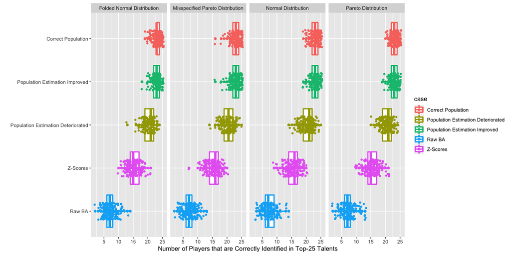

Each column of the plot indicates a different talent generation distribution. The first three rows of the plot are variants of our method. The first row displays the performance our method with the MLB eligible population correctly estimated. The second and third rows display the performance of our method with the MLB eligible population incorrectly estimated. In the second row, we underestimate the MLB eligible population where the estimation improves as time increases. In the third row, we underestimate the MLB eligible population where the estimation deteriorates as time increases. This configuration was chosen to be deliberately antagonistic to our method, especially when the talent generating process was misspecified. However, we see that our method correctly identifies more top-25 talented players than both Z-scores and raw unadjusted batting averages over 200 Monte Carlo iterations of this simulation study.

That being said, there is considerable overlap between the box plot in the third row and the box plot in the fourth row. This suggests that Z-scores may not be strictly worse than our method under misspecification. A more detailed look shows that this is not the case. Our method strictly beats Z-scores in terms of correctly identified top-25 talent in all but one iteration over all configurations (and is equivalent in the other iteration). The table below displays these results:

|  | Correct Pareto | Incorrect Pareto | Normal | Folded normal |
| --- | --- | --- | --- | --- |
| beats or tie | 200 | 200 | 200 | 200 |
| strictly beats | 200 | 200 | 199 | 200 |

## Rationale for choosing 1977 as the starting year

We now show why we choose 1977 as the starting year for comparing career trajectories. We investigated 50 similar trajectories computed with starting years from 1946 to 1995 and calculated the career bWAR rankings for the top players. The inner 80% range of bWAR rankings is depicted in the plot below. The ordering of names on the y-axis corresponds to the rankings given by the trajectory that starts in 1977. We see that the 1977 rankings fall within the range of rankings computed from the 49 other trajectories which makes it a good candidate starting point. We also investigated single-season reference years instead of trajectories. This method is much less stable as the balance between hitting and pitching and the distribution of bWAR are highly variable. Thus we went with trajectories and choose 1977 as the starting year.

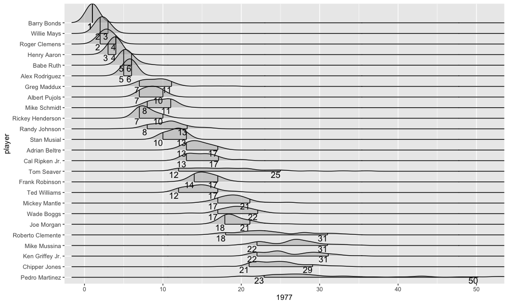

> This list is a moving target. I [Joe Posnanski] have done it [created an all-time list] three times using different methods and the rankings are quite different. This is because there’s no significant difference between a player ranked 72 and 48 and 31. I could swap them, for the most part, without it changing much of anything. So if you believe a player ranked 97th should actually be 53rd, well, it might be that way the next time.

## Other adjustment strategies: Era-bridging

We revisit some of the commentary about Berry, Reese, and Larkeys (BRL) [era-bridging method](https://www.vanderbilt.edu/psychological_sciences/graduate/programs/quantitative-methods/quantitative-content/berry_reese_larkey_1999.pdf) made in a [previous article](https://community.fangraphs.com/challenging-war-and-other-statistics-as-era-adjustment-tools/) by one of the authors. Recall that BRL developed an era-bridging technique involving hierarchical Bayesian models which they claim serves the role of a statistical time machine that allows for all players to be compared directly. They state:

> The goal is not to judge players relative to their contemporaries, but rather to compare all players directly. Hence the model that we use is a statistical time machine. We use additive models to estimate the innate ability of players, the effects of aging on performance, and the relative difficulty of each year within a sport. We measure each of these effects separated from the others. We use hierarchical models to model the distribution of players and specify separate distributions for each decade, thus allowing the “talent pool” within each sport to change. We study the changing talent pool in each sport and address Gould’s conjecture about the way in which populations change.”

BRL’s addressing of Gould’s conjecture is summarized with the following passage: “The globalization has been less pronounced in MLB, where players are drawn mainly from the United States and other countries in the Americas. Baseball has remained fairly stable within the United States, where it has been an important part of the culture for more than a century.”

**BRL’s rationale completely ignores segregation in its modeling construction, increases in the MLB eligible population relative to available roster spots, and increases in the average overall talent of that population.** It also downplays the demographic change in MLB produced by racial integration as noted by [Armour and Levitt](https://sabr.org/bioproj/topic/baseball-demographics-1947-2016/). In addition this model treats NL/AL players from all generations as interchangeable in the sense that they are all NL/AL caliber players regardless of which era they played. Plainly put, the expanded racial diversity of those performing in NL/AL literally meant white major leaguers who might have played a decade earlier were replaced by talented African American and Latino players that were previously excluded from MLB.

All of the above concerns are partially addressed by the modeling formulation which is parametric in nature and requires the complex changing dynamics to be captured by the parametric assumptions that they impose. In the previous article it was stated that:

> We found that BRL did not fully account for Gould’s conjecture in the context of baseball. We also found it odd that the BRL model predicts that a .300 hitter in 1996 will have a lower than .300 average for several seasons from 1900–20. This conflicts with the well-established notion that the talent of baseball players has improved over time. Perhaps the decadal hierarchical modeling approach did not capture the changing dynamics of the underlying talent pool or perhaps the distributional assumptions made were inappropriate.

While it is true that the BRL approach predicts that a .300 hitter in 1996 will have a lower than .300 average for several seasons from 1900–20, it is also true that the effects of deadball era shares blame with the notion that the talent of baseball players has improved over time. That being said, the Full House Model predicts that a .300 hitter in 1996 will have a greater than .300 average for all seasons in the 1900-20 period.

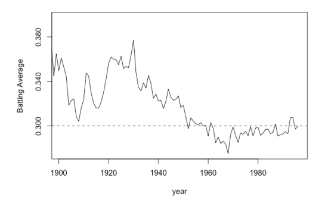

But it is perhaps each model’s handling of World War II (WWII) that best illustrates the short-comings of BRL’s era-bridging approach. According to Dan Olmsted at the The National WWII Museum [over 500 major leaguers served](https://www.nationalww2museum.org/war/wwii-polls/roper-polls-major-league-baseball-world-war-ii) in the military during World War II, including future Hall of Famers Ted Williams, Stan Musial, Hank Greenberg, Bob Feller, and Joe DiMaggio, not to mention the thousands of minor leaguers. There were at least 3 MLB players and 177 minor leaguers who were [killed in these wars](https://www.baseballsgreatestsacrifice.com/). This tally does not include far from complete [tally of the wounded](https://www.baseballsgreatestsacrifice.com/wounded_in_combat.html) or the sheer [number of soldiers](https://www.alternatewars.com/BBOW/Stats/US_Mil_Manpower_1789-1997.htm) that may have made a career out of the military or decided to pursue other professions than baseball after returning from war.

It is fair to say that WWII had gutted both the talent pool feeding into the MLB and talent level of the MLB. Our first thought would be to think that the gutted MLB would be readily apparent in a study of the changing distributions of baseball statistics. But this is not really the case. First of all, WAR is fixed to the number of possible wins and therefore exhibits no attachment to changing talent dynamics, the computation of WAR is the same regardless of the level of talent in the MLB. But certainly batting averages would be affected? No, not really. **WWII drained both the batters and the pitchers and the balance between the two was preserved. Thus the dynamics articulated by Steve Jay Gould take hold.** Here is a look at four statistical moments of the batting average distribution over time where the points in red correspond to seasons surrounding the peak of WWII (1941-1946):

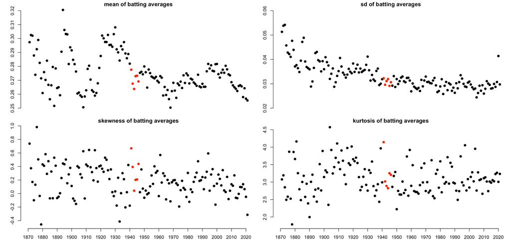

We can see that the distribution of batting averages during WWII seasons are not really any different than those of other seasons, and they do not differ dramatically from the batting average distributions of seasons immediately preceding and following WWII. **Therefore, BRL’s era-bridging hierarchical Bayesian method will not diagnose or correctly handle the WWII seasons. Their decadal and seasonal random effects will not reveal a difference in talent over those seasons. Therefore, era-bridging will overestimate the productivity of players during that time and will give false under projections for other player seasons which are mapped into the WWII baseball years.**

## Other adjustment strategies: Schell’s Method

Michael Schell has gone to great lengths to compare batters across eras in two books, [Baseball’s All-Time Best Hitters](https://press.princeton.edu/books/paperback/9780691123431/baseballs-all-time-best-hitters) and [Baseball’s All-Time Best Sluggers](https://press.princeton.edu/books/hardcover/9780691115573/baseballs-all-time-best-sluggers). Schell considers a wide-range of statistical adjustments in order to transform distributions of baseball statistics to something that is normal-like. Motivated by Gould, Schell also considers the standard deviation as a proxy for measuring a changing talent pool. He says: “We will call the season standard deviation of the park-adjusted average the performance spread, and will use it as a measure of the talent pool.” This approach suffers the same fate as era-bridging regarding the WWII seasons.

On page 58 in Baseball’s All-Time Best Sluggers, Schell outlines some problems with his standard deviation approach, he says (slightly paraphrasing):

> Someday we will need to abandon the use of the SD as a talent pool adjustment altogether and search for another talent pool adjustment method, likely involving more difficult statistical methods than those used in this book.

Our Full House Model answers Schell’s call. We abandon SD as a talent pool adjustment, and construct a model which incorporates the quality of the talent pool as a central component. We thank Michael Schell for his comprehensive adjustments and note that we use his park-factor adjustments in our work!

**We will close this part of our series by noting that there are several improvements to our Full House Modeling approach that can be made. Most notable among them is taking a deeper dive into what constitutes baseball interest, and investigating multivariate relationships between the statistics that we studied instead of viewing these statistics in isolation.**